# Home_Work_4

Group: BOB [Maryla Wozniak, Shakila Hoque, Elai Shalev, Matthew Perez]

11/8/2019

# Initial setup for following assignment

### Clearing the slate

In order to avoid potential issues while running the code it’s best to start with a fresh slate

```r
# THE FOLLOWING COMMAND WILL CLEAR ALL VARIABLES IN THE ENVIRONMENT
# SAVE ANY FILES OR DATA YOU WANT TO HOLD ONTO BEFORE RUNNING IT
rm(list = ls())
# THE FOLLOWING COMMAND CLEARS THE PLOT PANE AND MAY SAVE AND CLOSE
# ANY OPEN FILES YOU MAY BE EDITING
# SAVE ANY FILES OR DATA YOU WANT TO HOLD ONTO BEFORE RUNNING IT
# IF NO PLOTS AOR VISUALS ARE RUNNING IT WILL PRINT AN ERROR, IGNORE THAT.
dev.off()
```

```r
## NOTE: THE FOLLWOING SECTION WAS ADDED AFTER THE INITIAL
## INITIAL SUBMISSION OF THE PROJECT


## Step by step instructions
## Set the working dorectory to the location where the file was saved

## Setp: 1
## The 'rstudioapi' package allows you to access
## system information using the R language
## the 'getSourceEditorContext' function allows you
## to retreive informaton about the source files locaiton
## this includes the file path without you having to
## know where the fiole is. THe computer doest that work for you.

## rstudioapi::getSourceEditorContext()


## Step: 2
## The line above is of type 'list' meaning there are multiple
## peices of information contained within. In order to get the
## information we need we need to acess the file path
## under the 'path' acesor in the return of the functioncall
## to do that we append '$path' this will print the file
## path including the name of the file.

## rstudioapi::getSourceEditorContext()$path


## Step: 3
## In order to omit the name of the file from printing
## we can use the 'dirname' function that will ignore
## file names at the end of a file path and print
## only the path leading up to where the file is saved.

## dirname(rstudioapi::getSourceEditorContext()$path)


## Step: 4
## Lastly we use the 'setwd' comand to set the
## directory to the returned value of the entire function
## call in order to set the working directory to the
## locaiton of the file without ever having to look for where
## the file is actually stored.

## setwd(dirname(rstudioapi::getSourceEditorContext()$path))

## NOTE: THE LINES ABOVE ARE COMMENTED OUT IN ORDER TO
## PREVENT COMPILATION ERRORS IN 'RMD' AND OTHER 'TEX' BASED
## ENGINES. THIS IS A COMMAND IN ORDER TO SET YOUR WORKING
## DIRECTORY AND SHOULD BE COMMENTED OUT OR COMPLETELY
## OMITED FROM THE FINAL PRODUCT/PRESENTATION.
```

# Chapter: 08

## Questoin: 12

#### Apply boosting, bagging, and random forests to a data set of your choice. Be sure to fit the models on a training set and to evaluate their performance on a test set.

##### How accurate are the results compared to simple methods like linear or logistic regression?

##### Which of these approaches yields the best performance?

First we need to set up our working environment before performing the analysys.

```r
# IMPORT THE LIBR
# IMPORT LIBRARIES
suppressMessages(library(randomForest))
suppressMessages(library(gbm))
suppressMessages(library(tree))

# READ DATA FROM FILE
nba = read.csv("CIS_HW4.csv")

# PRINT COLUMN NAMES FOR REFERENCE LATER
names(nba)
```

```
##  [1] "Rk"     "Player" "Pos"    "Age"    "Tm"     "G"      "GS"
##  [8] "MP"     "FG"     "FGA"    "FG."    "X3P"    "X3PA"   "X3P."
## [15] "X2P"    "X2PA"   "X2P."   "eFG."   "FT"     "FTA"    "FT."
## [22] "ORB"    "DRB"    "TRB"    "AST"    "STL"    "BLK"    "TOV"
## [29] "PF"     "PTS"
```

```r
# REMOVE SPECIFIC COLUMNS AFTER REVIEWING THE DATA
nba = nba[,-c(1,2,3,7,11,14,17,18,21)]

# ATTACH DATA COLUMN NAMES
attach(nba)

# OMIT OBSERVATIONS BELOW 6 MINUTES OF PLAY TIME
nba = nba[nba$MP>6, ]

# CHECK FOR "NA" VALUES
colSums(is.na(nba))
```

```
##  Age   Tm    G   MP   FG  FGA  X3P X3PA  X2P X2PA   FT  FTA  ORB  DRB  TRB
##    0    0    0    0    0    0    0    0    0    0    0    0    0    0    0
##  AST  STL  BLK  TOV   PF  PTS
##    0    0    0    0    0    0
```

THE INITIAL SETUP IS FULLY COMPELETE NO NOW WE CAN PARTITION THE DATA

```r
# SPLIT DATA SET INTO TESTING AND TRAINING

# SET SEED TO SPECOOFC VALUE FOR REPRODUCTION OF WORK
set.seed(8)

# RANDOMLY SELECT ROWS FROM THE DATA SET
# SIZE IS HALF THE NUMBER OF OBSERVATIONS IN THE DATA SET
train_nba = sample(1:nrow(nba), nrow(nba)/2)
```

Now that the data has been partitioned we can applying boosting

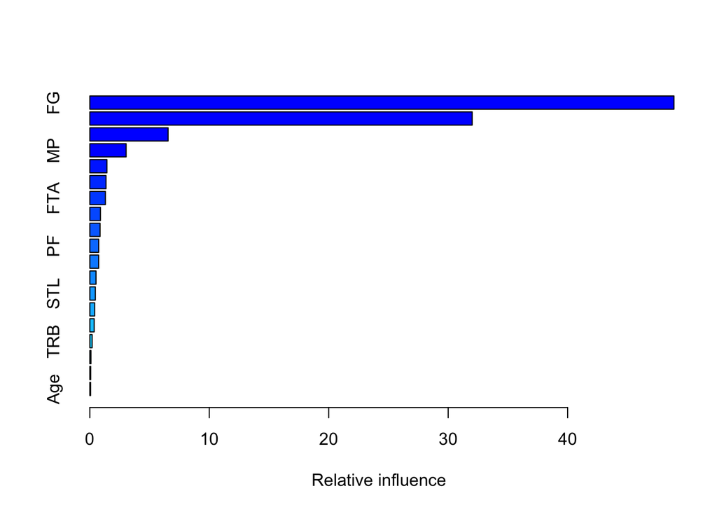

```
##       var     rel.inf
## FG     FG 48.90112993
## FGA   FGA 32.00988435
## FT     FT  6.55365868
## MP     MP  3.04009719
## X3PA X3PA  1.43160673
## X3P   X3P  1.35406013
## FTA   FTA  1.30424147
## DRB   DRB  0.88902766
## AST   AST  0.85837672
## PF     PF  0.74380575
## X2PA X2PA  0.73886754
## TOV   TOV  0.51721722
## STL   STL  0.46082941
## G       G  0.40485075
## X2P   X2P  0.36533134
## TRB   TRB  0.19289153
## BLK   BLK  0.09503044
## ORB   ORB  0.07511198
## Age   Age  0.06398116
```

```r
boost_nba = gbm(PTS~.-Tm, data = nba[train_nba,], distribution = "gaussian", n.trees = 5000, interaction.depth = 4)
summary(boost_nba)
```

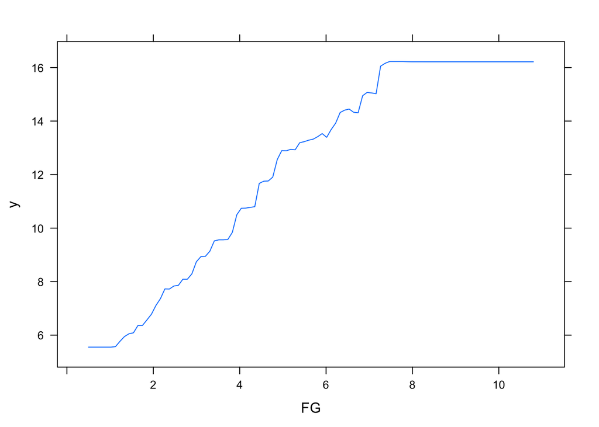

```r
par(mfrow = c(1,2))
plot(boost_nba, i="FG")
```

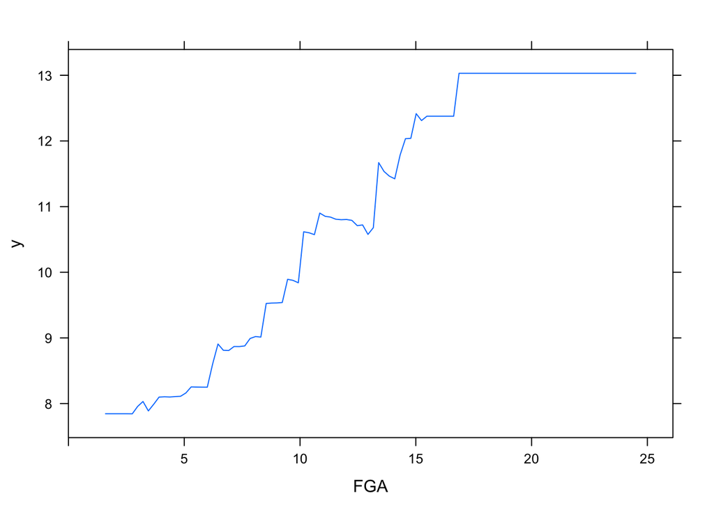

```r
plot(boost_nba, i="FGA")
```

```r
yhat.boost = predict(boost_nba, newdata = nba[-train_nba,], n.trees = 5000)
mean((yhat.boost - nba[-train_nba ,"PTS" ])^2)
```

```
## [1] 0.6475331
```

```r
# MSE for boosting is 0.6475331
```

Now that the data has been partitioned we can applying bagging

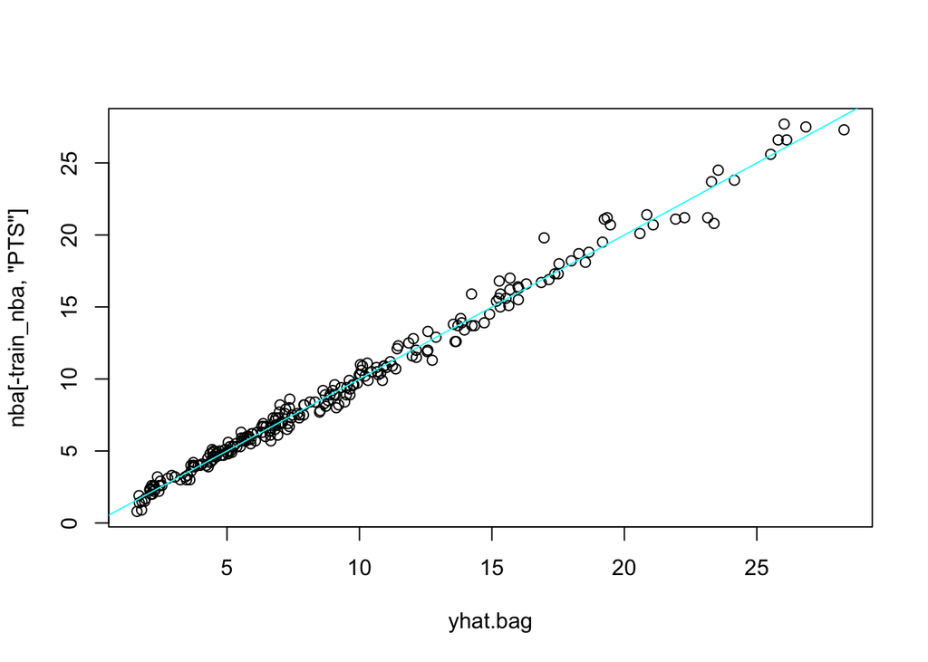

```r
bag_nba = randomForest(PTS~.-Tm ,data = nba, subset = train_nba, mtry = 19, importance = T)
yhat.bag = predict(bag_nba, newdata = nba[-train_nba,])
plot(yhat.bag, nba[-train_nba,"PTS"])
abline(0,1, col = 5)
```

```r
mean((yhat.bag - nba[-train_nba ,"PTS" ])^2)
```

```
## [1] 0.3524371
```

```r
#MSE for bagging is 0.3524371
```

```r
# applying random forest, cross-validating, and pruning the tree

tree_nba = tree(PTS~.-Tm, nba , subset = train_nba)
summary(tree_nba)
```

```
##
## Regression tree:
## tree(formula = PTS ~ . - Tm, data = nba, subset = train_nba)
## Variables actually used in tree construction:
## [1] "FG" "FT"
## Number of terminal nodes:  8
## Residual mean deviance:  1.505 = 353.6 / 235
## Distribution of residuals:
##      Min.   1st Qu.    Median      Mean   3rd Qu.      Max.
## -3.122000 -0.746200  0.009375  0.000000  0.693800  7.900000
```

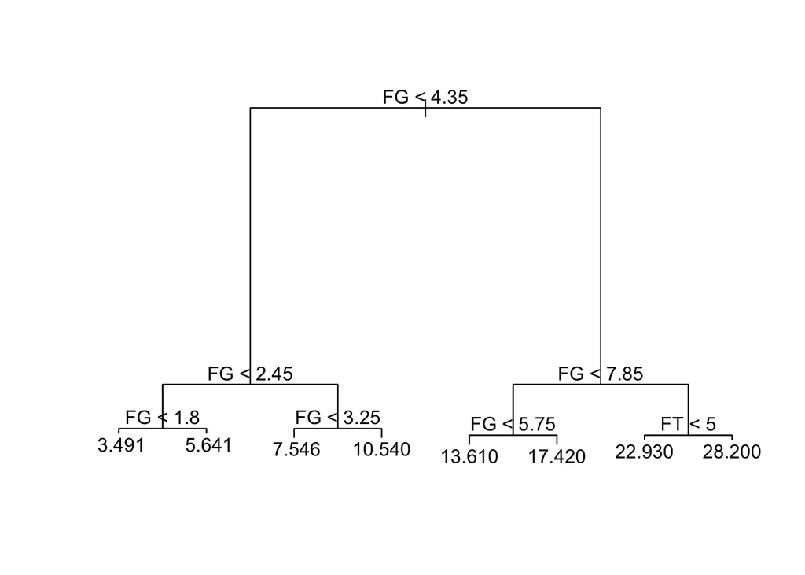

```r
plot(tree_nba)
text(tree_nba, pretty = 0)
```

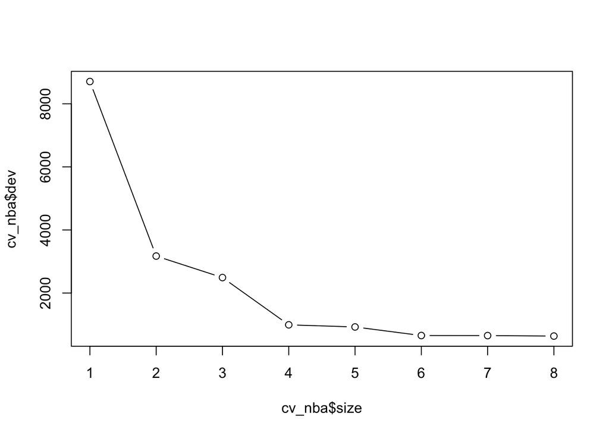

```r
cv_nba = cv.tree(tree_nba)
plot(cv_nba$size, cv_nba$dev, type = 'b')
```

```r
cv_nba
```

```
## $size
## [1] 8 7 6 5 4 3 2 1
##
## $dev
## [1]  634.7935  650.3714  652.3306  923.8901  991.4558 2490.4624 3171.9108
## [8] 8707.1177
##
## $k
## [1]       -Inf   89.77648   92.31593  180.51017  186.67052  917.69106
## [7] 1054.04712 5735.73600
##
## $method
## [1] "deviance"
##
## attr(,"class")
## [1] "prune"         "tree.sequence"
```

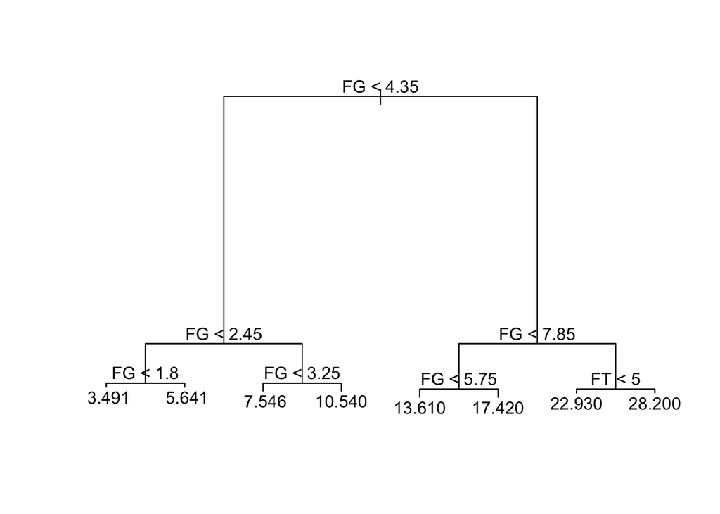

```r
pruning_nba = prune.tree(tree_nba, best = 8)
plot(pruning_nba)
text(pruning_nba, pretty = 0)
```